# First article supporting material

Crude and age-sex-year adjusted mortality rates and ratios and net survival

Author

Andrés González Santa Cruz

Published

August 21, 2025

# Data Loading and Exploration

## Loading Packages and uniting databases

Proceed to load the necessary packages.

```r
# --- Bootstrap reticulate con ruta relativa a getwd() ---
suppressPackageStartupMessages(library(reticulate))

# Busca .mamba_root/envs/py311/python.exe desde getwd() hacia padres
find_python_rel <- function(start = getwd(),
                            rel = file.path(".mamba_root","envs","py311","python.exe")) {
  cur <- normalizePath(start, winslash = "/", mustWork = FALSE)
  repeat {
    cand <- normalizePath(file.path(cur, rel), winslash = "/", mustWork = FALSE)
    if (file.exists(cand)) return(cand)
    parent <- dirname(cur)
    if (identical(parent, cur)) return(NA_character_)  # llegó a la raíz
    cur <- parent
  }
}

py <- find_python_rel()

if (is.na(py)) {
  stop("No se encontró Python relativo a getwd() (buscando '.mamba_root/envs/py311/python.exe').\n",
       "Directorio actual: ", getwd())
}

# Forzar ese intérprete
Sys.unsetenv(c("RETICULATE_CONDAENV","RETICULATE_PYTHON_FALLBACK"))
Sys.setenv(RETICULATE_PYTHON = py)
use_python(py, required = TRUE)

py_config()  # verificación

#:#:#:#:#:#:#:#:#:#:#:#:#:#:#:#:#:#:#:#:#:#:#:#:#:#:#:#:#:#:#:#:#:#:#:#:
#:#:#:#:#:#:#:#:#:#:#:#:#:#:#:#:#:#:#:#:#:#:#:#:#:#:#:#:#:#:#:#:#:#:#:#:#:#:#:#:
#:#:#:#:#:#:#:#:#:#:#:#:#:#:#:#:#:#:#:#:#:#:#:#:#:#:#:#:#:#:#:#:#:#:#:#:

#clean enviroment
rm(list = ls()); gc()
file.path(paste0(gsub("/cons","",gsub("cons","",paste0(getwd(),"/cons"))),"data/20241015_out"))

wdpath<-
paste0(gsub("/cons","",gsub("cons","",paste0(getwd(),"/cons"))))
wdpath

envpath<- if(regmatches(wdpath, regexpr("[A-Za-z]+", wdpath))=="G"){"G:/Mi unidad/Alvacast/SISTRAT 2023/"}else{"E:/Mi unidad/Alvacast/SISTRAT 2023/"}
envpath

time_before_dedup2<-Sys.time()

#base::load(paste0(wdpath,"data/20241015_out/","3_ndp_2025_05_30.Rdata"))
if (!(Sys.getenv("RSTUDIO_SESSION_TYPE") == "server" || file.exists("/.dockerenv"))) {
  file.path(paste0(gsub("/cons","",gsub("cons","",paste0(getwd(),"/cons"))),"data/20241015_out"))

  wdpath<-
  paste0(gsub("/cons","",gsub("cons","",paste0(getwd(),"/cons"))))
  wdpath

  envpath<- if(regmatches(wdpath, regexpr("[A-Za-z]+", wdpath))=="G"){"G:/Mi unidad/Alvacast/SISTRAT 2023/"}else{"E:/Mi unidad/Alvacast/SISTRAT 2023/"}
  envpath

  base::load(paste0(wdpath,"data/20241015_out/","4_ndp_2025_06_06.Rdata"))

  } else {
    file.path(paste0(getwd(),"/_input"))
    paste0(getwd(),"/_input","/4_ndp_2025_06_06.Rdata")
    base::load(paste0(getwd(),"/_input","/4_ndp_2025_06_06.Rdata.enc"))
  }

time_before_dedup1<-Sys.time()
password <- Sys.getenv("PASS_PPIO")
system(sprintf("7z x path/to/_input/4_ndp_2025_06_06.Rdata.7z.001 -p'%s'", password))

try(rm("HOSP_filter_pl_filt"))
```

```
python:         G:/My Drive/Alvacast/SISTRAT 2023/.mamba_root/envs/py311/python.exe
libpython:      G:/My Drive/Alvacast/SISTRAT 2023/.mamba_root/envs/py311/python311.dll
pythonhome:     G:/My Drive/Alvacast/SISTRAT 2023/.mamba_root/envs/py311
version:        3.11.5 | packaged by conda-forge | (main, Aug 27 2023, 03:23:48) [MSC v.1936 64 bit (AMD64)]
Architecture:   64bit
numpy:           [NOT FOUND]

NOTE: Python version was forced by RETICULATE_PYTHON
          used (Mb) gc trigger  (Mb) max used  (Mb)
Ncells 1739268 92.9    2609282 139.4  2609282 139.4
Vcells 3212755 24.6    8388608  64.0  5079521  38.8
[1] "G:/My Drive/Alvacast/SISTRAT 2023//data/20241015_out"
[1] "G:/My Drive/Alvacast/SISTRAT 2023//"
[1] "G:/Mi unidad/Alvacast/SISTRAT 2023/"
[1] 127
```

```r
#https://github.com/rstudio/renv/issues/544
#renv falls back to copying rather than symlinking, which is evidently very slow in this configuration.
renv::settings$use.cache(FALSE)

#only use explicit dependencies (in DESCRIPTION)
renv::settings$snapshot.type("implicit")

#check if rstools is installed
try(installr::install.Rtools(check_r_update=F))
```

Installing package into ‘G:/My Drive/Alvacast/SISTRAT 2023/renv/library/windows/R-4.4/x86_64-w64-mingw32’ (as ‘lib’ is unspecified)

```r
if(quarto::quarto_version()<"1.7.29"){
stop("You need to install a recent quarto version")   # la publicada el 28-abr-2025
}

#change repository to CL
local({
  r <- getOption("repos")
  r["CRAN"] <- "https://cran.dcc.uchile.cl/"
  options(repos=r)
})

if(!require(pacman)){install.packages("pacman");require(pacman)}
```

Cargando paquete requerido: pacman

```r
if(!require(pak)){install.packages("pak");require(pak)}
```

Cargando paquete requerido: pak

```r
pacman::p_unlock(lib.loc = .libPaths()) #para no tener problemas reinstalando paquetes
```

No 00LOCK detected in: G:/My Drive/Alvacast/SISTRAT 2023/renv/library/windows/R-4.4/x86_64-w64-mingw32 No 00LOCK detected in: C:/Program Files/R/R-4.4.1/library

```r
if(Sys.info()["sysname"]=="Windows"){
if (getRversion() != "4.4.1") { stop("Requires R version 4.4.1; Actual: ", getRversion()) }
}

#check docker
check_docker_running <- function() {
  # Try running 'docker info' to check if Docker is running
  system("docker info", intern = TRUE, ignore.stderr = TRUE)
}

install_docker <- function() {
  # Open the Docker Desktop download page in the browser for installation
  browseURL("https://www.docker.com/products/docker-desktop")
}

# Main logic
if (inherits(try(check_docker_running(), silent = TRUE), "try-error")) {
  liftr::install_docker()
} else {
  message("Docker is running.")
}
```

Warning in system(“docker info”, intern = TRUE, ignore.stderr = TRUE): el comando ejecutado ‘docker info’ tiene el estatus 1

Docker is running.

```r
#Registrar el font
windowsFonts(`Times New Roman` = windowsFont("TT Times New Roman"))

#_#_#_#_#_#_#_#_#_#_#_#_#_#_#_#_#_#_#_#_#_#_#_#_#_#_#_#_#_#_#_#_#_#_#_#_#_#_#_#_
#PACKAGES#######################################################################
#_#_#_#_#_#_#_#_#_#_#_#_#_#_#_#_#_#_#_#_#_#_#_#_#_#_#_#_#_#_#_#_#_#_#_#_#_#_#_#_

unlink("*_cache", recursive=T)

# ----------------------------------------------------------------------
# 2. Use a single pak::pkg_install() call for most CRAN packages
# ----------------------------------------------------------------------

paks <-
  c(#"git",
    # To connect to github
    "gh", #interface for  GitHub API from R
    #
    "gitcreds", # manages Git credentials (usernames, passwords, tokens)
    #
    "usethis", # simplifies common project setup tasks for R developers
    # Package to bring packages in development
    "devtools",
    # Package administration
    "renv",
    # To manipulate data
    "knitr", "pander", "DT",
    # Join
    "fuzzyjoin", "RecordLinkage",
    # For tables
    "tidyverse", "janitor",
    # For contingency tables
    "kableExtra",
    # For connections with python
    "reticulate",
    # To manipulate big data
    "polars", "sqldf",
    # To bring big databases
    "nanoparquet",
    # Interface for R and RStudio in R
    "installr", "rmarkdown", "quarto", "yaml", #"rstudioapi",
    # Time handling
    "clock",
    # Combine plots
    "ggpubr",
    # Parallelized iterative processing
    "furrr",
    # Work like a tibble with a data.table database
    "tidytable",
    # Split database into training and testing
    "caret",
    # Impute missing data
    "missRanger", "mice",
    # To modularize tasks
    "job",
    # For PhantomJS install checks
    "webshot"
  )

# dplyr
# janitor
# reshape2
# tidytable
# arrow
# boot
# broom
# car
# caret
# data.table
# DiagrammeR
# DiagrammeRsvg
# dplyr
# epiR
# epitools
# ggplot2
# glue
# htmlwidgets
# knitr
# lubridate
# naniar
# parallel
# polycor
# pROC
# psych
# readr
# rio
# rsvg
# scales
# stringr
# tableone
# rmarkdown
# biostat3
# codebook
# finalfit
# Hmisc
# kableExtra
# knitr
# devtools
# tidyr
# stringi
# stringr
# muhaz
# sqldf
# compareGroups
# survminer
# lubridate
# ggfortify
# car
# fuzzyjoin
# compareGroups
# caret
# job
# htmltools
# nanoparquet
# ggpubr
# polars
# installr
# clock
# pander
# reshape
# mice
# missRanger
# VIM
# withr
# biostat3
# broom
# glue
# finalfit
# purrr
# sf


# pak::pkg_install(paks)

pak::pak_sitrep()
# pak::sysreqs_check_installed(unique(unlist(paks)))
#pak::lockfile_create(unique(unlist(paks)),  "dependencies_duplicates24.lock", dependencies=T)
#pak::lockfile_install("dependencies_duplicates24.lock")
#https://rdrr.io/cran/pak/man/faq.html
#pak::cache_delete()

library(tidytable)
```

Adjuntando el paquete: ‘tidytable’

The following objects are masked from ‘package:stats’:

```
dt, filter, lag
```

The following object is masked from ‘package:base’:

```
%in%
```

```r
library(polars)
```

Warning: package ‘polars’ was built under R version 4.4.3

```r
library(ggplot2)
library(readr)


if (!require("pacman")) install.packages("pacman")

pacman::p_load(
  mexhaz,      # Flexible parametric hazard regression models for survival analysis
  tidyverse,   # Collection of packages for data manipulation, visualization, and more (includes dplyr, ggplot2, tidyr, etc.)
  janitor,     # Simple tools for examining and cleaning dirty data
  tableone,    # Create "Table 1" summaries for descriptive statistics in medical research
  cowplot,     # Streamlined plot theme and plot annotations for ggplot2
  grid,        # Base R package for low-level graphics functions (used for arranging plots)
  rio,         # Simplifies data import/export with a consistent interface
  coin,        # Conditional inference procedures for hypothesis testing
  kableExtra,  # Enhances 'knitr::kable()' for creating complex tables in R Markdown
  epitools,    # Epidemiological tools for data analysis
  relsurv,     # Relative survival analysis for population-based cancer studies
  survminer,   # Survival analysis and visualization based on 'survival' package
  biostat3,    # Biostatistics functions and datasets for teaching and research
  tableone,    # (Repeated) Create descriptive summary tables for clinical research
  popEpi,      # For SMRs and SIR
  metafor,     # For heterogeneity test /Cochrane Q
  parallel,    # Parallel computing (for bootstrap)
  install = T  # Automatically install packages if not already installed
)

# ----------------------------------------------------------------------
# 3. Activate polars code completion (safe to try even if it fails)
# ----------------------------------------------------------------------
try(polars_code_completion_activate())
```

Using code completion in ‘native’ mode.

```r
# ----------------------------------------------------------------------
# 4. BPMN from GitHub (not on CRAN, so install via devtools if missing)
# ----------------------------------------------------------------------
if (!requireNamespace("bpmn", quietly = TRUE)) {
  devtools::install_github("bergant/bpmn")
}

# ----------------------------------------------------------------------
# 5. PhantomJS Check (use webshot if PhantomJS is missing)
# ----------------------------------------------------------------------
# if (!webshot::is_phantomjs_installed()) {
#   webshot::install_phantomjs()
# }

#_#_#_#_#_#_#_#_#_#_#_#_#_#_#_#_#_#_#_#_#_#_#_#_#_#_#_#_#_#_#_#_#_#_#_#_#_#_#_#_
#FUNCTIONS######################################################################
#_#_#_#_#_#_#_#_#_#_#_#_#_#_#_#_#_#_#_#_#_#_#_#_#_#_#_#_#_#_#_#_#_#_#_#_#_#_#_#_

copiar_nombres <- function(x,row.names=FALSE,col.names=TRUE,dec=",",...) {
  if(class(try(dplyr::ungroup(x)))[1]=="tbl_df"){
    if(options()$OutDec=="."){
      options(OutDec = dec)
      write.table(format(data.frame(x)),"clipboard",sep="\t",row.names=FALSE,col.names=col.names,...)
      options(OutDec = ".")
      return(x)
    } else {
      options(OutDec = ",")
      write.table(format(data.frame(x)),"clipboard",sep="\t",row.names=FALSE,col.names=col.names,...)
      options(OutDec = ",")
      return(x)
    }
  } else {
    if(options()$OutDec=="."){
      options(OutDec = dec)
      write.table(format(x),"clipboard",sep="\t",row.names=FALSE,col.names=col.names,...)
      options(OutDec = ".")
      return(x)
    } else {
      options(OutDec = ",")
      write.table(format(x),"clipboard",sep="\t",row.names=FALSE,col.names=col.names,...)
      options(OutDec = ",")
      return(x)
    }
  }
}

#WINDOWS do not restrict memory size
if(.Platform$OS.type == "windows") withAutoprint({
  memory.size()
  memory.size(TRUE)
  memory.limit()
})
```

Warning: ‘memory.size()’ is no longer supported

Warning: ‘memory.size()’ is no longer supported

Warning: ‘memory.limit()’ is no longer supported

```r
memory.limit(size=56000)
```

Warning: ‘memory.limit()’ is no longer supported

```r
#:#:#:#:#:#:#:#:#:#:#:#:#:#:#:#:#:#:#:#:#:#:#:#:#:#:#:#:#:#:#:#:#:#:#:#:#:#:#:#:#:#:#:#:#:#:#:#:#:#:#:#:#:#:#:
#NAs are replaced with "" in knitr kable
options(knitr.kable.NA = '')

pander::panderOptions('big.mark', ',')
pander::panderOptions('decimal.mark', '.')

#:#:#:#:#:#:#:#:#:#:#:#:#:#:#:#:#:#:#:#:#:#:#:#:#:#:#:#:#:#:#:#:#:#:#:#:#:#:#:#:#:#:#:#:#:#:#:#:#:#:#:#:#:#:#:
#
#to format rows in bold
format_cells <- function(df, rows ,cols, value = c("italics", "bold", "strikethrough")){

  # select the correct markup
  # one * for italics, two ** for bold
  map <- setNames(c("*", "**", "~~"), c("italics", "bold", "strikethrough"))
  markup <- map[value]

  for (r in rows){
    for(c in cols){

      # Make sure values are not factors
      df[[c]] <- as.character( df[[c]])

      # Update formatting
      df[r, c] <- ifelse(nchar(df[r, c])==0,"",paste0(markup, gsub(" ", "", df[r, c]), markup))
    }
  }

  return(df)
}
#To produce line breaks in messages and warnings
knitr::knit_hooks$set(
   error = function(x, options) {
     paste('\n\n<div class="alert alert-danger" style="font-size: small !important;">',
           gsub('##', '\n', gsub('^##\ Error', '**Error**', x)),
           '</div>', sep = '\n')
   },
   warning = function(x, options) {
     paste('\n\n<div class="alert alert-warning" style="font-size: small !important;">',
           gsub('##', '\n', gsub('^##\ Warning:', '**Warning**', x)),
           '</div>', sep = '\n')
   },
   message = function(x, options) {
     paste('<div class="message" style="font-size: small !important;">',
           gsub('##', '\n', x),
           '</div>', sep = '\n')
   }
)

#:#:#:#:#:#:#:#:#:#:#:#:#:#:#:#:#:#:#:#:#:#:#:#:#:#:#:#:#:#:#:#:#:#:#:#:#:#:#:#:#:#:#:#:#:#:#:#:#:#:#:#:#:#:#:

sum_dates <- function(x){

  cbind.data.frame(
min= as.Date(min(unclass(as.Date(x)), na.rm=T), origin = "1970-01-01"),
p001= as.Date(quantile(unclass(as.Date(x)), .001, na.rm=T), origin = "1970-01-01"),
p005= as.Date(quantile(unclass(as.Date(x)), .005, na.rm=T), origin = "1970-01-01"),
p025= as.Date(quantile(unclass(as.Date(x)), .025, na.rm=T), origin = "1970-01-01"),
p25= as.Date(quantile(unclass(as.Date(x)), .25, na.rm=T), origin = "1970-01-01"),
p50= as.Date(quantile(unclass(as.Date(x)), .5, na.rm=T), origin = "1970-01-01"),
p75= as.Date(quantile(unclass(as.Date(x)), .75, na.rm=T), origin = "1970-01-01"),
p975= as.Date(quantile(unclass(as.Date(x)), .975, na.rm=T), origin = "1970-01-01"),
p995= as.Date(quantile(unclass(as.Date(x)), .995, na.rm=T), origin = "1970-01-01"),
p999= as.Date(quantile(unclass(as.Date(x)), .999, na.rm=T), origin = "1970-01-01"),
max= as.Date(max(unclass(as.Date(x)), na.rm=T), origin = "1970-01-01")
  )
}

#:#:#:#:#:#:#:#:#:#:#:#:#:#:#:#:#:#:#:#:#:#:#:#:#:#:#:#:#:#:#:#:#:#:#:#:#:#:#:#:#:#:#:#:#:#:#:#:#:#:#:#:#:#:#:

# Define the function adapted for Polars
sum_dates_polars <- function(df, date_col) {
  # Create the list of quantiles
  quantiles <- c(0.001, 0.005, 0.025, 0.25, 0.5, 0.75, 0.975, 0.995, 0.999)
  # Create expressions to calculate min and max
  expr_list <- list(
    pl$col(date_col)$min()$alias("min"),
    pl$col(date_col)$max()$alias("max")
  )
  # Add expressions for quantiles
  for (q in quantiles) {
    expr_list <- append(expr_list, pl$col(date_col)$quantile(q)$alias(paste0("p", sub("\\.", "", as.character(q)))))
  }
  # Apply the expressions and return a DataFrame with the results
  df$select(expr_list)
}

# Custom function for sampling with a seed
sample_n_with_seed <- function(data, size, seed) {
  set.seed(seed)
  dplyr::sample_n(data, size)
}

# Function to get the most frequent value
most_frequent <- function(x) {
  uniq_vals <- unique(x)
  freq_vals <- sapply(uniq_vals, function(val) sum(x == val))
  most_freq <- uniq_vals[which(freq_vals == max(freq_vals))]

  if (length(most_freq) == 1) {
    return(most_freq)
  } else {
    return(NA)
  }
}
#_#_#_#_#_#_#_#_#_#_#_#_#_#_#_#_#_#_#_#_#_#_#_#_#_#_#_#_#_#_#_#_#_#_#_#_#_#_#_#_
#CONFIG #######################################################################
#_#_#_#_#_#_#_#_#_#_#_#_#_#_#_#_#_#_#_#_#_#_#_#_#_#_#_#_#_#_#_#_#_#_#_#_#_#_#_#_

options(scipen=2) #display numbers rather scientific number

#_#_#_#_#_#_#_#_#_#_#_#_#_#_#_#_#_#_#_#_#_#_#_#_#_#_#_#_#_#_#_#_#_#_#_#_#_#_#_#_

# Define the function first
#oins these values with semicolons and optionally truncates the result if it exceeds a specified width.
toString2 <- function(x, width = NULL, ...) {
    string <- paste(x, collapse = "; ")
    if (missing(width) || is.null(width) || width == 0)
        return(string)
    if (width < 0)
        stop("'width' must be positive")
    if (nchar(string, type = "w") > width) {
        width <- max(6, width)
        string <- paste0(substr(string, 1, width - 3), "...")
    }
    string
}




extract_fit <- function(modelo) {
  logLik_value <- modelo$loglik
  # n_params <- attr(logLik_value, "df")
  # n_obs <- length(modelo$y)
  n_params <- modelo$n.par
  n_obs <- modelo$n.obs #no sé si mejor n.obs.tot
  convergence_code <- modelo$code # Check convergence status (0, 1, or 2)

  aic <- 2 * modelo$n.par - 2 * modelo$loglik
  bic <- log(modelo$n.obs) * modelo$n.par - 2 * modelo$loglik

  data.frame(
    LogLikelihood = as.numeric(logLik_value),
    NumParameters = n_params,
    NumObservations = n_obs,
    AIC = aic,
    BIC = bic,
    convergence = convergence_code
  )
}
calculate_smr_orig = function(data) {
  data|>
    summarise(
      Observed = sum(observed),
      Expected = sum(expected)
    )|>
    rowwise()|>
    mutate(
      SMR = Observed / Expected,
      lo = biostat3::poisson.ci(Observed, Expected)[1],
      up = biostat3::poisson.ci(Observed, Expected)[2]
    )|>
    ungroup()
}
calculate_smr = function(data) {
  data|>
    summarise(
      Observed = sum(observed, na.rm=T),
      Expected = sum(expected, na.rm=T)
    )|>
    rowwise()|>
    mutate(
      SMR = Observed / Expected,
      lo = biostat3::poisson.ci(Observed, Expected)[1],
      up = biostat3::poisson.ci(Observed, Expected)[2]
    )|>
    ungroup()
}
```

```r
calculate_smr_alt <- function(data) {
  data|>
    summarise(
      Observed = sum(observed),
      Expected = sum(expected)
    )|>
    rowwise()|>
    mutate(
      # Reemplazar Expected == 0 con un valor pequeño
      Expected = ifelse(Expected == 0, 1e-5, Expected),
      Observed = ifelse(Observed == 0, 1e-5, Observed),
      SMR = Observed / Expected,
      lo = biostat3::poisson.ci(Observed, Expected)[1],
      up = biostat3::poisson.ci(Observed, Expected)[2]
    )|>
    ungroup()
}


theme_sjPlot_manual <- function() {
  theme(
    plot.title = element_text(size = 16, face = "bold"),
    axis.title.x = element_text(size = 14),
    axis.title.y = element_text(size = 14),
    axis.text.x = element_text(size = 12),
    axis.text.y = element_text(size = 12),
    panel.background = element_rect(fill = "white"),
    panel.grid.major = element_line(color = "gray80"),
    panel.grid.minor = element_line(color = "gray90")
  )
}
summarize_numerical_tt <- function(df, var) {

  df <- as_tidytable(df)[!is.na(status)]   # drop rows with missing status

  # ── 1. summaries by status ──────────────────────────────────────
  by_status <- df %>%
    tidytable::summarise(
      Total  = .N,
      Mean   = sprintf("%.1f", mean(get(var), na.rm = TRUE)),
      SD     = sprintf("%.1f", sd(get(var),  na.rm = TRUE)),
      Median = sprintf("%.1f", median(get(var), na.rm = TRUE)),
      IQR    = sprintf("%.1f", IQR(get(var),   na.rm = TRUE)),
      Min    = sprintf("%.1f", min(get(var),   na.rm = TRUE)),
      Max    = sprintf("%.1f", max(get(var),   na.rm = TRUE)),
      pres   = sprintf("%.1f [%.1f-%.1f]",
                       median(get(var), na.rm = TRUE),
                       quantile(get(var), .25, na.rm = TRUE),
                       quantile(get(var), .75, na.rm = TRUE)),
      .by = status
    )|> tidytable::mutate(status= as.character(status))

  # ── 2. overall (Total) row ──────────────────────────────────────
  overall <- df %>%
    tidytable::summarise(
      Total  = .N,
      Mean   = sprintf("%.1f", mean(get(var), na.rm = TRUE)),
      SD     = sprintf("%.1f", sd(get(var),  na.rm = TRUE)),
      Median = sprintf("%.1f", median(get(var), na.rm = TRUE)),
      IQR    = sprintf("%.1f", IQR(get(var),   na.rm = TRUE)),
      Min    = sprintf("%.1f", min(get(var),   na.rm = TRUE)),
      Max    = sprintf("%.1f", max(get(var),   na.rm = TRUE)),
      pres   = sprintf("%.1f [%.1f-%.1f]",
                       median(get(var), na.rm = TRUE),
                       quantile(get(var), .25, na.rm = TRUE),
                       quantile(get(var), .75, na.rm = TRUE))
    ) %>%
    mutate(status = "Total")

  # ── 3. bind and return ──────────────────────────────────────────
  bind_rows(by_status, overall) |>
    dplyr::mutate(status = factor(status, levels = c("Total", "0", "1"))) |>
    arrange(status)
}
summarize_categorical_tt <- function(.data, var) {
  var  <- rlang::as_name(rlang::ensym(var))    # make sure it’s a plain string
  tbl  <- as_tidytable(.data)                  # guarantee tidytable class

  ## ── counts per status ──────────────────────────────────────────────
  tab <- tbl %>%
    tidytable::summarise(
      n   = .N,
      .by = c("status", var)                  # fast group-by in tidytable
    ) %>%
    pivot_wider(
      names_from  = status,
      values_from = n,
      values_fill = 0
    ) %>%
    mutate(Total = rowSums(across(where(is.numeric))))

  ## ── build “count (pct)” strings ────────────────────────────────────
  status_cols <- setdiff(names(tab), c(var, "Total"))
  status_cols <- sort(status_cols, na.last = TRUE)  # ensure "0" then "1", etc.
  pct_cols    <- c("Total", status_cols)

  tab <- tab %>%
    tidytable::mutate(
      across(
        all_of(pct_cols),
        \(x) paste0(x, " (", sprintf("%.1f", x / sum(x) * 100), ")"),
        .names = "{.col}_pct"
      )
    )

  ## ── keep only the pct columns in required order ────────────────────
  tab %>%
    tidytable::select(all_of(c(var, "Total_pct", paste0(status_cols, "_pct"))))
}
#SISTRAT23_c1_2010_2022_df_prev1q_sel3a_surv SISTRAT23_c1_2010_2022_df_prev1q_sel3b_surv
# treatment modality
# substance use at treatment entry
# initial treatment outcome
# days in treatment
# age at treatment entry
# year of treatment initiation


#:#:#:#:#:#:#:#:#:#:#:#:#:#:#:#:#:#:#:#:#:#:#:#:#:#:#:#:#:#:#:#:#:#:#:#:#:#:#:#:
#:#:#:#:#:#:#:#:#:#:#:#:#:#:#:#:#:#:#:#:#:#:#:#:#:#:#:#:#:#:#:#:#:#:#:#:#:#:#:#:
#:#:#:#:#:#:#:#:#:#:#:#:#:#:#:#:#:#:#:#:#:#:#:#:#:#:#:#:#:#:#:#:#:#:#:#:#:#:#:#:

year_fraction <- function(dates) {
  dates <- as.Date(dates)  # Ensure input is Date class

  years <- as.numeric(format(dates, "%Y"))
  day_of_year <- as.numeric(format(dates, "%j"))

  # Function to check leap year
  is_leap_year <- function(year) {
    (year %% 4 == 0 & year %% 100 != 0) | (year %% 400 == 0)
  }

  days_in_year <- ifelse(is_leap_year(years), 366, 365)

  years + (day_of_year - 1) / days_in_year
}
cmr_ci_phi <- function(observed, pyrs,
                   phi = 1,           # escala de sobre-dispersión
                   conf.level = 0.95,
                   factor = 1000) {

  # Validación básica
  if (any(is.na(observed) | is.na(pyrs)))
    stop("NAs no permitidos; limpia antes los datos.")
  if (any(observed < 0 | pyrs <= 0))
    stop("observed ≥ 0 y pyrs > 0 son obligatorios.")

  z <- qnorm(1 - (1 - conf.level) / 2)

  # CMR
  cmr <- observed / pyrs * factor

  # IC
  ci_low  <- ci_high <- numeric(length(observed))

  zeros <- observed == 0
  if (any(zeros)) {
    # Límite gamma exacto cuando hay cero muertes
    ci_low[zeros]  <- 0
    ci_high[zeros] <- qgamma(conf.level, shape = 1,
                             rate  = pyrs[zeros]) * factor
  }
  if (any(!zeros)) {
    # Log-normal con sobre-dispersión
    se_log <- sqrt(phi / observed[!zeros])
    ci_low[!zeros]  <- cmr[!zeros] * exp(-z * se_log)
    ci_high[!zeros] <- cmr[!zeros] * exp( z * se_log)
  }

  data.frame(CMR = cmr,
             CI_low = ci_low,
             CI_high = ci_high)
}
```

```r
invisible("using sir output")
sir_ci_phi_improved <- function(sir_obj, phi, conf.level = 0.95) {
  #Método log-normal, the best, dont overestimate, or subestimate variance
  # extract totals
  total_obs <- sir_obj$observed
  total_exp <- sir_obj$expected

  # Calculate SEs
  theta <- total_obs / total_exp
    # Normal approximation, n>20
  # Corrected SEs (McCullagh & Nelder, 1989)
  # “For ratios of Poisson means (such as SIR or CMR), the appropriate approach is to use multinomial or binomial models conditioned on the total observed.”
  # Breslow NE, Day NE. Statistical Methods in Cancer Research, Vol. II (IARC, 1987), §2.2. – Derives the same SE formula and recommends inflating by φ in the presence of heterogeneity.
  z <- qnorm(1 - (1 - conf.level)/2)

  se_log <- sqrt(phi / total_obs)  # Valid formula

  # ICs
  lci <- theta * exp(-z * se_log)
  uci <- theta * exp(z * se_log)

  data.frame(
    SIR = theta,
    CI_low = lci,
    CI_high = uci,
    phi_used = phi
  )
}
invisible("using glmdf")
sir_ci_phi_improved2 <- function(observed, expected, phi = 1, conf.level = 0.95) {
    z <- qnorm(1 - (1 - conf.level)/2)
    theta <- observed / expected

    # SE en escala logarítmica con ajuste φ
    se_log <- sqrt(phi / observed)

    # ICs multiplicativos (correctos para ratios)
    lci <- theta * exp(-z * se_log)
    uci <- theta * exp(z * se_log)

    list(
        SIR = theta,
        CI_low = lci,
        CI_high = uci
    )
}

#We estimated the dispersion parameter (φ) for each subgroup by fitting an intercept-only quasi-Poisson model. This method assumes no major unmeasured heterogeneity within subgroups. While this may slightly overestimate dispersion due to residual confounding, it yields conservative confidence intervals that maintain the nominal coverage (Breslow and Day, 1987)
sir_cmr_subgroup <- function(df, group_var, phi = NULL) {

    sir_ci_phi_row <- function(observed, expected, phi) {
      sir_ci_phi_improved(
        list(observed = observed, expected = expected),
        phi
      )
    }

    # 1. Compute summary statistics by group
    group_stats <- df %>%
        dplyr::group_by(dplyr::across(dplyr::all_of(group_var))) %>%
        dplyr::summarise(
            observed = sum(from0to1, na.rm = TRUE),
            pyrs = sum(pyrs, na.rm = TRUE),
            expected = sum(expected, na.rm = TRUE),
            .groups = "drop"
        ) %>%
        dplyr::mutate(
            sir = observed / expected,
            ear = (observed - expected) / pyrs * 1000
        )

    # 2. Compute dispersion parameter (phi) for each group if not provided
    if (is.null(phi)) {
        phi_vals <- df %>%
            dplyr::group_by(dplyr::across(dplyr::all_of(group_var))) %>%
            dplyr::group_modify(~ {
                # Skip groups with no events
                if (sum(.x$from0to1, na.rm = TRUE) == 0) {
                    return(data.frame(phi = NA_real_))
                }

                # Fit quasi-Poisson model
                mod <- tryCatch(
                    stats::glm(
                        from0to1 ~ 1,
                        family = quasipoisson,
                        offset = log(expected),
                        data = .x
                    ),
                    error = function(e) NULL
                )

                if (is.null(mod)) return(data.frame(phi = NA_real_))
                data.frame(phi = summary(mod)$dispersion)
            }) %>%
            dplyr::ungroup()

        group_stats <- dplyr::left_join(group_stats, phi_vals, by = group_var)
    } else {
        group_stats$phi <- phi
    }

    # 3. Compute confidence intervals
    result <- group_stats %>%
        dplyr::mutate(
            # Compute CMR with CI
            cmr_ci = purrr::pmap(
                list(observed, pyrs, phi),
                function(obs, py, p) {
                    cmr_ci_phi(obs, py, p)
                }
            ),
            # Compute SIR with CI
            sir_ci = purrr::pmap(
                list(observed, expected, phi),
                function(obs, exp, p) {
                    sir_ci_phi_improved2(obs, exp, p)
                }
            )
        ) %>%
        dplyr::mutate(
            # Format CMR values
            CMR_1000 = purrr::map_chr(cmr_ci, ~ sprintf(
                "%.1f (%.1f-%.1f)", .x$CMR, .x$CI_low, .x$CI_high
            )),
            # Format SIR values
            SMR = purrr::map_chr(sir_ci, ~ sprintf(
                "%.6f (%.6f-%.6f)", .x$SIR, .x$CI_low, .x$CI_high
            ))
        )

    # 4. Final formatting - AHORA INCLUYE PHI
    result %>%
        dplyr::mutate(
            expected = round(expected, 0),
            pyrs = round(pyrs, 0),
            EAR = sprintf("%.2f", ear),
            # Formatear phi con 3 decimales
            phi_fmt =  phi
        ) %>%
        dplyr::select(
            dplyr::all_of(group_var),
            observed,
            pyrs,
            CMR_1000,
            expected,
            SMR,
            EAR,
            phi = phi_fmt  # Nueva columna con phi formateado
        )
}

#2025-06-16
#For indirect SMRs (log(expected))
extract_phi <- function(df) {
  df_glm <- df %>%
    left_join(mx_1x1_banded, by = c("agegroup", "year", "sex")) %>%
    mutate(expected = pyrs * haz)

  # Modelo con variables de estratificación
  model_poisson <- glm(
    from0to1 ~ factor(agegroup) + factor(sex) + factor(year),
    family = poisson,
    offset = log(expected),
    data = df_glm
  )

  # Cálculo robusto de φ
  pearson_chisq <- sum(residuals(model_poisson, type = "pearson")^2)
  df_residual <- df.residual(model_poisson)
  dispersion_index <- pearson_chisq / df_residual

  return(dispersion_index)
}

#etract phi for a directly standardized mortality rates
extract_phi_dsr <- function(df) {
  df_glm <- df %>%
    left_join(mx_1x1_banded, by = c("agegroup", "year", "sex")) %>%
    mutate(expected = pyrs * haz)

  # model with stratification variables
  model_poisson <- glm(
    from0to1 ~ factor(agegroup) + factor(sex) + factor(year),
    family = poisson,
    offset = log(pyrs),
    data = df_glm
  )
```

```r
  # Cálculo robusto de φ
  pearson_chisq <- sum(residuals(model_poisson, type = "pearson")^2)
  df_residual <- df.residual(model_poisson)
  dispersion_index <- pearson_chisq / df_residual

  return(dispersion_index)
}

#Fay & Feuer (1997). Confidence intervals for directly standardized rates: a
#method based on the gamma distribution. Stat Med 16:791-801.
dsr_format <- function(rate, se, phi = 1, factor = 1e3, digits = 2, conf = 0.95) {
  z <- qnorm(1 - (1 - conf)/2)
  sprintf(paste0("%.", digits, "f (%.", digits, "f–%.", digits, "f)"),
          rate*factor,
          pmax(0, (rate - z*se*sqrt(phi))*factor),
          (rate + z*se*sqrt(phi))*factor)
}
dsr_format_corr <- function(rate, se, phi = 1,
                       factor = 1e4,       # multiplica la tasa (p. ej. ×100 000)
                       digits = 2,         # decimales a mostrar
                       conf   = 0.95) {    # nivel de confianza
  z  <- qnorm(1 - (1 - conf) / 2)
  se <- se * sqrt(phi)                     # sobredispersión
  se_log <- ifelse(rate > 0, se / rate, NA)

  L <- rate * exp(-z * se_log)
  U <- rate * exp( z * se_log)

  sprintf(paste0("%.", digits, "f (%.", digits, "f–%.", digits, "f)"),
          rate * factor, L * factor, U * factor)
}

extract_spline_data <- function(x) {
  if (is.null(x$spline.seq.A)) stop('No splines found.')

  plotdim <- as.numeric(c(!is.null(x$spline.seq.A),
                          !is.null(x$spline.seq.B),
                          !is.null(x$spline.seq.C)))
  splines <- c('spline.seq.A', 'spline.seq.B', 'spline.seq.C')[1:sum(plotdim)]
  ests <- gsub("seq", "est", splines)

  library(tidyr)
  library(dplyr)

  all_data <- lapply(seq_along(splines), function(i) {
    spline_name <- splines[i]
    est_name <- ests[i]

    # Extract spline sequence and estimates
    spline_seq <- x[[spline_name]]
    est_df <- x[[est_name]]

    # Check if est_df has a factor/level column (usually first column)
    if (ncol(est_df) >= 4) {
      # Assuming first column is level, next columns are estimate, lower CI, upper CI
      df <- data.frame(
        spline = x$spline[i],
        spline_value = spline_seq,
        level = est_df[,1],
        estimate = est_df[,2],
        lower_ci = est_df[,3],
        upper_ci = est_df[,4]
      )
    } else {
      # If no levels, just estimates and CIs
      df <- data.frame(
        spline = x$spline[i],
        spline_value = spline_seq,
        estimate = est_df[,1],
        lower_ci = est_df[,2],
        upper_ci = est_df[,3]
      )
    }
    return(df)
  })

  # Combine all spline data into one data frame
  combined_df <- bind_rows(all_data)

  return(combined_df)
}

hetero <- function(rrr1, lcl1, ucl1, rrr2, lcl2, ucl2) {
    # Calcular varianzas en escala logarítmica
    z <- qnorm(0.975)
    var1 <- ((log(ucl1) - log(rrr1)) / z)^2
    var2 <- ((log(ucl2) - log(rrr2)) / z)^2

    # Estimación agrupada
    log_rrr1 <- log(rrr1)
    log_rrr2 <- log(rrr2)
    pooled_log <- (log_rrr1/var1 + log_rrr2/var2) / (1/var1 + 1/var2)
    pooled <- exp(pooled_log)

    # Cochran's Q
    q_val <- ((log_rrr1 - pooled_log)^2)/var1 + ((log_rrr2 - pooled_log)^2)/var2
    p_val <- pchisq(q_val, df = 1, lower.tail = FALSE)

    # Test de interacción de Altman
    d_log <- log_rrr1 - log_rrr2
    se1 <- (log(ucl1) - log(lcl1)) / (2*z)
    se2 <- (log(ucl2) - log(lcl2)) / (2*z)
    se_d <- sqrt(se1^2 + se2^2)
    z_test <- d_log / se_d
    p_inter <- 2 * pnorm(-abs(z_test))

    # Intervalos de confianza
    ci_diff <- c(d_log - z*se_d, d_log + z*se_d)
    ci_ratio <- exp(ci_diff)

    # Salida con formato idéntico al de Stata
    cat("First RRR (95% CI): ", sprintf("%4.2f (%4.2f, %4.2f)\n", rrr1, lcl1, ucl1))
    cat("Second RRR (95% CI): ", sprintf("%4.2f (%4.2f, %4.2f)\n\n", rrr2, lcl2, ucl2))
    cat("Pooled RRR =", sprintf("%4.2f\n", pooled))
    cat("Cochran's Q =", sprintf("%4.2f", q_val), " p-value =", sprintf("%5.4f\n\n", p_val))

    cat("Altman test for interaction\n\n")
    cat("Diff in log RRRs:", sprintf("%5.3f\n", d_log))
    cat("95% CI for diff: (", sprintf("%4.3f, %4.3f)\n", ci_diff[1], ci_diff[2]))
    cat("Test of interaction: z =", sprintf("%5.3f", z_test), " p =", sprintf("%5.4f\n", p_inter))
    cat("Ratio of estimates, 95% CI:", sprintf("%4.2f (%4.2f, %4.2f)\n",
                                               exp(d_log), ci_ratio[1], ci_ratio[2]))
}
pairwise_smr_test <- function(smrs, lowers, uppers, alpha = 0.05) {
  # Validate inputs
  stopifnot(
    length(smrs) == length(lowers),
    length(smrs) == length(uppers),
    alpha > 0, alpha < 1
  )

  # Calculate SEs from 95% CIs (FIXED confidence level)
  # Original data uses 95% CIs -> use z = 1.96 regardless of 'alpha'
  z_ci <- qnorm(0.975)  # 1.96 for 95% CI
  ses <- (uppers - lowers) / (2 * z_ci)

  # Generate pairwise comparisons
  n <- length(smrs)
  group_names <- paste("Group", 1:n)
  comparisons <- combn(n, 2, simplify = FALSE)

  # Calculate differences, SEs, z-scores, p-values
  results <- lapply(comparisons, function(pair) {
    i <- pair[1]
    j <- pair[2]

    data.frame(
      group1 = group_names[i],
      group2 = group_names[j],
      smr1 = smrs[i],
      smr2 = smrs[j],
      difference = smrs[i] - smrs[j],
      se_diff = sqrt(ses[i]^2 + ses[j]^2)
    )
  }) |> do.call(what = rbind)

  # Add z-scores and p-values
  results$z <- abs(results$difference) / results$se_diff
  results$p_unadj <- 2 * pnorm(-results$z)

  # Apply Holm-Bonferroni correction
  results$p_holm <- p.adjust(results$p_unadj, method = "holm")

  # Significance labels
  results$significance <- cut(
    results$p_holm,
    breaks = c(-Inf, 0.001, 0.01, 0.05, Inf),
    labels = c("***", "**", "*", "NS")
  )

  return(results)
}
```

[output not shown]

**Note**

Loads and cleans databases of substance use disorder treatments and mortality in Chile, generating adjusted mortality rates and standardized mortality ratios. Additionally, calculates net survival using survival analysis techniques and compares observed mortality with that expected according to age, year, and sex.

## Import & format database

```r
SISTRAT23_c1_2010_2022_df_prev1q_sel<-
SISTRAT23_c1_2010_2022_df_prev1q[, c("rn",
        "hash_key",
        "adm_age_rec2",#"adm_yr_rec",
        "birth_date_rec",#"birth_date_rec_imp",
        "adm_date_rec2",#"adm_date_rec",
        "adm_date_num_rec2",#"adm_date_rec_num",
        "TABLE",#"TABLE_rec",
        "dit_rec6",#"dit_rec",
        "disch_date_num_rec6",#"disch_date_num",
        "disch_date_rec6",
        "tr_compliance_rec3",#motivo_de_egreso",
        "primary_sub",#"sustancia_principal",
        "second_sub1",#"sustancia_principal",
        "second_sub2",#"sustancia_principal",
        "second_sub3",#"sustancia_principal",
        "sub_dep_icd10_status",#"diagnostico_trs_consumo_sustancia",
        "sex_rec", #"sexo",
        "municipallity_res_cutpre18",#"comuna_residencia",
        "region_del_centro",#
        "evaluacion_del_proceso_terapeutico",
        "edad_inicio_consumo",
        "ed_attainment",
        "plan_type"# treatment modality
)]
```

We counted the amount of duplicate records in terms of HASH and admission age, and then we discard.

```r
SISTRAT23_c1_2010_2022_df_prev1q_sel|>
  janitor::get_dupes(hash_key, adm_age_rec2)|>  nrow()
rows_with_dupes<-SISTRAT23_c1_2010_2022_df_prev1q_sel|>
  janitor::get_dupes(hash_key, adm_age_rec2)|>
  pull(rn)

SISTRAT23_c1_2010_2022_df_prev1q_sel2<-SISTRAT23_c1_2010_2022_df_prev1q_sel|>
  (\(df) {
    nrow(df)->>before_disc_dup_hash_age_adm_nrow
    cat(paste0("1.Number of cases before discarding duplicates in admission age and hash key: ", formatC(nrow(df), big.mark=",")),"\n")
    cat(paste0("1.Number of patients before discarding duplicates in admission age and hash key: ", formatC(nrow(distinct(df, hash_key)), big.mark=",")),"\n")
  cat(paste0("Records with unavailable missing days in treatment (eg., currently in treatment): ",df |> mutate(years_in_tr= time_length(interval(adm_date_rec2, disch_date_rec6), unit="year")) |>
      filter(is.na(years_in_tr)) |> nrow(), "\n"));
    cat(paste0("Records with negative days in treatment: ",df |> mutate(years_in_tr= time_length(interval(adm_date_rec2, disch_date_rec6), unit="year")) |>
      filter(years_in_tr<0)|>  nrow(), "\n")) ;
    cat(paste0("Records with more than 3 years in treatment: ",df |> mutate(years_in_tr= time_length(interval(adm_date_rec2, disch_date_rec6), unit="year")) |>
      filter(years_in_tr>3)|> nrow(), "\n"))
  df
  })()|>
  mutate(years_in_tr= time_length(interval(adm_date_rec2, disch_date_rec6), unit="year"))|>
  filter(!is.na(years_in_tr)|years_in_tr>=0|years_in_tr<=3)|>
  group_by(hash_key, adm_age_rec2)|>
  slice_max(dit_rec6)|>
  ungroup()|>
  (\(df) {
    nrow(df)->>after_disc_dup_hash_age_adm_nrow
    cat(paste0("1.Number of cases after discarding duplicates in admission age and hash key and validating days in treatment: ", formatC(nrow(df), big.mark=",")),"\n")
    cat(paste0("1.Number of patients after discarding duplicates in admission age and hash key and validating days in treatment: ", formatC(nrow(distinct(df, hash_key)), big.mark=",")),"\n")
    df
  })()

cat("Discarded rows\n")
before_disc_dup_hash_age_adm_nrow-after_disc_dup_hash_age_adm_nrow #before 18-06 there was  150,019 , p= 106,283 as a result in this step
```

```
[1] 54
1.Number of cases before discarding duplicates in admission age and hash key: 150,046
1.Number of patients before discarding duplicates in admission age and hash key: 106,283
Records with unavailable missing days in treatment (eg., currently in treatment): 4007
Records with negative days in treatment: 8
Records with more than 3 years in treatment: 1039
1.Number of cases after discarding duplicates in admission age and hash key and validating days in treatment: 146,012
1.Number of patients after discarding duplicates in admission age and hash key and validating days in treatment: 103,612
Discarded rows
[1] 4034
```

At this date, i only have data until 2020. I also joined mortlaity database with SENDA treatments. We selected records of treatments between 2010 and 2020, of patients admitted between 18 and 64 years old.

```r
cat("Make the death date\n")
mortality$death_date <-
  as.Date(paste0(mortality$ano_def, "-",
                 sprintf("%02.0f",mortality$mes_def), "-",
                 mortality$dia_def))

cat("Maximum death date available:\n")
max(mortality$death_date, na.rm=T)
#[1] "2020-12-31"

SISTRAT23_c1_2010_2022_df_prev1q_sel2_surv<-
  SISTRAT23_c1_2010_2022_df_prev1q_sel2 |>
  tidytable::left_join(mortality[,c("hashkey", "death_date")], by=c("hash_key"="hashkey"), multiple="first") |>
  tidytable::mutate(status=ifelse(is.na(death_date), 0, 1))

SISTRAT23_c1_2010_2022_df_prev1q_sel2_surv <- as_tidytable(SISTRAT23_c1_2010_2022_df_prev1q_sel2_surv)


SISTRAT23_c1_2010_2022_df_prev1q_sel3a_surv<-
  SISTRAT23_c1_2010_2022_df_prev1q_sel2_surv|>
  (\(df) {
    cat(paste0("3a. Before discarding cases, cases, 2010-2019, first treatment: ", formatC(nrow(df), big.mark=",")),"\n")
    cat(paste0("3a. Before discarding cases, patients, 2010-2019, first treatment: ", formatC(nrow(distinct(df, hash_key)), big.mark=",")),"\n")
    nrow(df)->> before_df3a_nrow
    df
  })() |>
  tidytable::arrange(hash_key, adm_age_rec2)|>
  #treatments between 2010 and 2020
  tidytable::filter(adm_date_rec2>="2010-01-01", adm_date_rec2<"2020-12-31")|>
  tidytable::group_by(hash_key) |>
  tidytable::mutate(tto= tidytable::row_number())|>
  tidytable::slice_min(tto)|>
  tidytable::ungroup()|>
  #admission ages between 18-65
  tidytable::filter(adm_age_rec2>=18, adm_age_rec2<65)|>
  tidytable::mutate(post_ttos=ifelse(tto>1, 1, 0))|>
  (\(df) {
    cat(paste0("3a.Number of cases, 2010-2019, first treatment: ", formatC(nrow(df), big.mark=",")),"\n")
    cat(paste0("3a.Number of patients, 2010-2019, first treatment: ", formatC(nrow(distinct(df, hash_key)), big.mark=",")),"\n")
    nrow(df)->> after_df3a_nrow
    df
  })()

cat("Discarded records:\n")
before_df3a_nrow-after_df3a_nrow
```

```
Make the death date
Maximum death date available:
[1] "2020-12-31"
3a. Before discarding cases, cases, 2010-2019, first treatment: 146,014
3a. Before discarding cases, patients, 2010-2019, first treatment: 103,612
3a.Number of cases, 2010-2019, first treatment: 88,774
3a.Number of patients, 2010-2019, first treatment: 88,774
Discarded records:
[1] 57240
```

We construct the database of sensitivity analyses, count previous treatments, but i get the last treatment(3b)

```r
SISTRAT23_c1_2010_2022_df_prev1q_sel3b_surv<-
  SISTRAT23_c1_2010_2022_df_prev1q_sel2_surv|>
  (\(df) {
    cat(paste0("3b. Before discarding cases, cases, 2010-2019, last treatment: ", formatC(nrow(df), big.mark=",")),"\n")
    cat(paste0("3b. Before discarding cases, patients, 2010-2019, last treatment: ", formatC(nrow(distinct(df, hash_key)), big.mark=",")),"\n")
    nrow(df)->> before_df3b_nrow
    df
  })() |>
  #tidytable::filter(TABLE<2021)|>
  tidytable::arrange(hash_key, adm_age_rec2)|>
  #treatments between 2010 and 2020
  tidytable::filter(adm_date_rec2>="2010-01-01", adm_date_rec2<"2020-12-31")|>
  tidytable::group_by(hash_key) |>
  tidytable::mutate(tto= tidytable::row_number())|>
  tidytable::slice_max(tto)|>
  tidytable::ungroup()|>
  #admission ages between 18-65 (85,763 - 84,502)= 84.897
  tidytable::filter(adm_age_rec2>=18, adm_age_rec2<65)|>
  tidytable::mutate(prev_ttos=ifelse(tto>1, 1, 0))|>
  (\(df) {
    cat(paste0("3b.Number of cases, 2010-2019, last (LVCF) treatment: ", formatC(nrow(df), big.mark=",")),"\n")
    cat(paste0("3b.Number of patients, 2010-2019, last (LVCF) treatment: ", formatC(nrow(distinct(df, hash_key)), big.mark=",")),"\n")
    nrow(df)->> after_df3b_nrow
    df
  })()


cat("Discarded records:\n")
before_df3b_nrow-after_df3b_nrow
```

```
3b. Before discarding cases, cases, 2010-2019, last treatment: 146,014
3b. Before discarding cases, patients, 2010-2019, last treatment: 103,612
3b.Number of cases, 2010-2019, last (LVCF) treatment: 88,725
3b.Number of patients, 2010-2019, last (LVCF) treatment: 88,725
Discarded records:
[1] 57289
```

Discarded ongoing treatments (truncated, death or currently in treatment, o referrals to teratments outside SENDA network).

```r
days_years<- 365.2425

SISTRAT23_c1_2010_2022_df_prev1q_sel4a_surv<-
  SISTRAT23_c1_2010_2022_df_prev1q_sel3a_surv|>
  (\(df) {
    nrow(df)->>df4a_nrow_pre
    cat(paste0("Discarded (death, no tr. compliance), cases(4a): ", formatC(nrow(tidytable::filter(df, is.na(tr_compliance_rec3) | tr_compliance_rec3=="death"|grepl("truncated|currently|referral", tr_compliance_rec3))), big.mark=",")),"\n")
    cat(paste0("Discarded (death, no tr. compliance), patients(4a): ", formatC(nrow(distinct(tidytable::filter(df, is.na(tr_compliance_rec3) | tr_compliance_rec3=="death"|grepl("truncated|currently|referral", tr_compliance_rec3)), hash_key)), big.mark=",")),"\n")
  df
    })()|>
  tidytable::filter(!is.na(tr_compliance_rec3) & tr_compliance_rec3!="death" & !grepl("truncated|currently|referral", tr_compliance_rec3))|>
  # calculamos la edad al egreso
  tidytable::mutate(disch_age_rec= (dit_rec6/365.241)+adm_age_rec2)|>
  tidytable::mutate(timesurv= tidytable::case_when(
    status==1~ time_length(interval(adm_date_rec2, death_date), unit="year"),
    status==0~ time_length(interval(adm_date_rec2, as.Date("2020-12-31")), unit="year")))|>
  tidytable::mutate(death_date_rec= tidytable::case_when(
    status==1~ death_date,
    status==0~ as.Date("2020-12-31")))|>
  tidytable::mutate(death_age_rec= as.integer(timesurv+adm_age_rec2))|>
  (\(df) {
    cat(paste0("4a.Number of cases: ", formatC(nrow(df), big.mark=",")),"\n")
    cat(paste0("4a.Number of patients: ", formatC(nrow(distinct(df, hash_key)), big.mark=",")),"\n")
    nrow(df) ->>df4a_nrow_post
    df
  })()
cat("Discarded records:\n")
df4a_nrow_pre-df4a_nrow_post

cat("Records were excluded for patients who had not yet been discharged")
 paste0(round(((df4a_nrow_pre-df4a_nrow_post)/222945)*100,1),"%")
```

```
Discarded (death, no tr. compliance), cases(4a): 14,304
Discarded (death, no tr. compliance), patients(4a): 14,304
4a.Number of cases: 74,470
4a.Number of patients: 74,470
Discarded records:
[1] 14304
Records were excluded for patients who had not yet been discharged[1] "6.4%"
```

We replicated for thae database of the last recorded treatments.

```r
SISTRAT23_c1_2010_2022_df_prev1q_sel4b_surv<-
  SISTRAT23_c1_2010_2022_df_prev1q_sel3b_surv|>
  (\(df) {
    cat(paste0("Discarded (death, no tr. compliance), cases(4b): ", formatC(nrow(tidytable::filter(df, is.na(tr_compliance_rec3) | tr_compliance_rec3=="death"|grepl("truncated|currently|referral", tr_compliance_rec3))), big.mark=",")),"\n")
    cat(paste0("Discarded (death, no tr. compliance), patients(4b): ", formatC(nrow(distinct(tidytable::filter(df, is.na(tr_compliance_rec3) | tr_compliance_rec3=="death"|grepl("truncated|currently|referral", tr_compliance_rec3)), hash_key)), big.mark=",")),"\n")
    nrow(df) ->>df4b_nrow_pre
    df
  })()|>
  tidytable::filter(!is.na(tr_compliance_rec3) & tr_compliance_rec3!="death" & !grepl("truncated|currently|referral", tr_compliance_rec3))|>  # calculamos la edad al egreso
  tidytable::mutate(disch_age_rec= (dit_rec6/365.241)+adm_age_rec2)|>
  tidytable::mutate(death_date_rec= tidytable::case_when(
    status==1~ death_date,
    status==0~ as.Date("2020-12-31")))|>
   tidytable::mutate(timesurv= tidytable::case_when(
    status==1~ time_length(interval(adm_date_rec2, death_date), unit="year"),
    status==0~ time_length(interval(adm_date_rec2, as.Date("2020-12-31")), unit="year")))|>
  tidytable::mutate(death_age_rec= as.integer(timesurv+adm_age_rec2))|>
  (\(df) {
    cat(paste0("4b.Number of cases: ", formatC(nrow(df), big.mark=",")),"\n")
    cat(paste0("4b.Number of patients: ", formatC(nrow(distinct(df, hash_key)), big.mark=",")),"\n")
    nrow(df) ->>df4b_nrow_post
    df
  })()

cat("Discarded records:\n")
df4b_nrow_pre-df4b_nrow_post

cat("Records were excluded for patients who had not yet been discharged")
 paste0(round(((df4b_nrow_pre-df4b_nrow_post)/222945)*100,1),"%")
```

```
Discarded (death, no tr. compliance), cases(4b): 11,340
Discarded (death, no tr. compliance), patients(4b): 11,340
4b.Number of cases: 77,385
4b.Number of patients: 77,385
Discarded records:
[1] 11340
Records were excluded for patients who had not yet been discharged[1] "5.1%"
```

```r
SISTRAT23_c1_2010_2022_df_prev1q_sel4c_surv<-
  SISTRAT23_c1_2010_2022_df_prev1q_sel3a_surv|>
  (\(df) {
    nrow(df)->>df4c_nrow_pre
    cat(paste0("Discarded (death, no tr. compliance), cases(4c): ", formatC(nrow(tidytable::filter(df, is.na(tr_compliance_rec3) | tr_compliance_rec3=="death"|grepl("truncated|currently|referral", tr_compliance_rec3))), big.mark=",")),"\n")
    cat(paste0("Discarded (death, no tr. compliance), patients(4c): ", formatC(nrow(distinct(tidytable::filter(df, is.na(tr_compliance_rec3) | tr_compliance_rec3=="death"|grepl("truncated|currently|referral", tr_compliance_rec3)), hash_key)), big.mark=",")),"\n")
  df
    })()|>
  # calculamos la edad al egreso
  tidytable::mutate(disch_age_rec= (dit_rec6/365.241)+adm_age_rec2)|>
  tidytable::mutate(timesurv= tidytable::case_when(
    status==1~ time_length(interval(adm_date_rec2, death_date), unit="year"),
    status==0~ time_length(interval(adm_date_rec2, as.Date("2020-12-31")), unit="year")))|>
  tidytable::mutate(death_date_rec= tidytable::case_when(
    status==1~ death_date,
    status==0~ as.Date("2020-12-31")))|>
  tidytable::mutate(death_age_rec= as.integer(timesurv+adm_age_rec2))|>
  (\(df) {
    cat(paste0("4c.Number of cases: ", formatC(nrow(df), big.mark=",")),"\n")
    cat(paste0("4c.Number of patients: ", formatC(nrow(distinct(df, hash_key)), big.mark=",")),"\n")
    nrow(df) ->>df4c_nrow_post
    df
  })()
cat("Discarded records:\n")
df4c_nrow_pre-df4c_nrow_post

cat("Records were excluded for patients who had not yet been discharged")
 paste0(round(((df4c_nrow_pre-df4c_nrow_post)/222945)*100,1),"%")
```

```
Discarded (death, no tr. compliance), cases(4c): 14,304
Discarded (death, no tr. compliance), patients(4c): 14,304
4c.Number of cases: 88,774
4c.Number of patients: 88,774
Discarded records:
[1] 0
Records were excluded for patients who had not yet been discharged[1] "0%"
```

Added admission age and year

```r
SISTRAT23_c1_2010_2022_df_prev1q_sel4a_surv$adm_age_rec2_int <- as.integer(SISTRAT23_c1_2010_2022_df_prev1q_sel4a_surv$adm_age_rec2)
SISTRAT23_c1_2010_2022_df_prev1q_sel4b_surv$adm_age_rec2_int <- as.integer(SISTRAT23_c1_2010_2022_df_prev1q_sel4b_surv$adm_age_rec2)
#add admission year
SISTRAT23_c1_2010_2022_df_prev1q_sel4a_surv$yr_adm <- floor(year(SISTRAT23_c1_2010_2022_df_prev1q_sel4a_surv$adm_date_rec2))
SISTRAT23_c1_2010_2022_df_prev1q_sel4b_surv$yr_adm <- floor(year(SISTRAT23_c1_2010_2022_df_prev1q_sel4b_surv$adm_date_rec2))


SISTRAT23_c1_2010_2022_df_prev1q_sel4c_surv$adm_age_rec2_int <- as.integer(SISTRAT23_c1_2010_2022_df_prev1q_sel4c_surv$adm_age_rec2)
SISTRAT23_c1_2010_2022_df_prev1q_sel4c_surv$yr_adm <- floor(year(SISTRAT23_c1_2010_2022_df_prev1q_sel4c_surv$adm_date_rec2))
```

## Bring & format mortality tables

Import and format tables for compatibility

```r
# Importar los archivos desde la ruta base
base_path <- paste0(getwd(),"/_input/")

mltper_1x1 <- try(rio::import(paste0(base_path, "mltper_1x1.txt")))
fltper_1x1 <- try(rio::import(paste0(base_path, "fltper_1x1.txt")))
mltper_5x1 <- try(rio::import(paste0(base_path, "mltper_5x1.txt")))
fltper_5x1 <- try(rio::import(paste0(base_path, "fltper_5x1.txt")))

mltper_1x10 <- try(rio::import(paste0(base_path, "mltper_1x10.txt")))
fltper_1x10 <- try(rio::import(paste0(base_path, "fltper_1x10.txt")))
mltper_5x10 <- try(rio::import(paste0(base_path, "mltper_5x10.txt")))
fltper_5x10 <- try(rio::import(paste0(base_path, "fltper_5x10.txt")))

#filtro para obtener las tasas de los últimos 10 años
mltper_1x10_filt<-mltper_1x10[mltper_1x10$Year=="2010-2019",]
fltper_1x10_filt<-fltper_1x10[fltper_1x10$Year=="2010-2019",]

mltper_5x10_filt<-mltper_5x10[mltper_5x10$Year=="2010-2019",]
fltper_5x10_filt<-fltper_5x10[fltper_5x10$Year=="2010-2019",]


mltper_1x1_filt<-mltper_1x1[between(mltper_1x1$Year,2010,2020),]
fltper_1x1_filt<-fltper_1x1[between(fltper_1x1$Year,2010,2020),]

mltper_5x1_filt<-mltper_5x1[between(mltper_5x1$Year,2010,2020),]
fltper_5x1_filt<-fltper_5x1[between(fltper_5x1$Year,2010,2020),]

#cambiar la edad a entero
mltper_1x10_filt$age_rec <- as.numeric(mltper_1x10_filt$Age)
```

Warning: NAs introducidos por coerción

```r
fltper_1x10_filt$age_rec <- as.numeric(fltper_1x10_filt$Age)
```

Warning: NAs introducidos por coerción

```r
mltper_5x1_filt$age_rec <- as.numeric(mltper_5x1_filt$Age)
```

Warning: NAs introducidos por coerción

```r
fltper_5x1_filt$age_rec <- as.numeric(fltper_5x1_filt$Age)
```

Warning: NAs introducidos por coerción

```r
mltper_1x10_filt$sex <- "male"
fltper_1x10_filt$sex <- "female"
mltper_5x10_filt$sex <- "male"
fltper_5x10_filt$sex <- "female"
mltper_1x1_filt$sex <- "male"
fltper_1x1_filt$sex <- "female"
mltper_5x1_filt$sex <- "male"
fltper_5x1_filt$sex <- "female"

cons_rate_sex_1x10<-
  rbind.data.frame(mltper_1x10_filt, fltper_1x10_filt)[,c("age_rec","sex", "qx","mx")]
cons_rate_sex_1x10<-cons_rate_sex_1x10[which(!is.na(cons_rate_sex_1x10$age_rec)),]
cons_rate_sex_1x10$lambda_p <- -log( 1 - cons_rate_sex_1x10$qx ) / 365.241

cons_rate_sex_5x10<-
  rbind.data.frame(mltper_5x10_filt, fltper_5x10_filt)[,c("Age","sex", "lx", "qx","mx")]
cons_rate_sex_5x10$lambda_p <- -log( 1 - cons_rate_sex_5x10$qx ) / 365.241
invisible("Capping valores cercanos al 100% muertes")
invisible("No esn ecesario porque not engo esos casos")
cons_rate_sex_5x10<-cons_rate_sex_5x10[which(cons_rate_sex_5x10$Age!="110+"),]

cons_rate_sex_5x1<-
  rbind.data.frame(mltper_5x1_filt, fltper_5x1_filt)[,c("Year","Age","sex", "lx","qx","mx")]
cons_rate_sex_5x1$lambda_p <- -log( 1 - cons_rate_sex_5x1$qx ) / 365.241
invisible("Capping valores cercanos al 100% muertes")
invisible("No esn ecesario porque not engo esos casos")
cons_rate_sex_5x1<-cons_rate_sex_5x1[which(cons_rate_sex_5x1$Age!="110+"),]
```

Import mortality tables from National Statistics Institute, along with projections of the population.

```r
tablas_de_mortalidad_de_chile_1992_2050_agrupada <-
  readxl::read_excel(paste0(base_path, "tablas-de-mortalidad-de-chile-1992-2050.xlsx"),
                     sheet = "BD Tablas de Mortalidad", skip = 1)|>
  janitor::clean_names()|>
  dplyr::filter(ano>=2010, ano<=2020)|>
  dplyr::mutate(edad= readr::parse_number(edad))|>
  dplyr::filter(edad>=18, edad<65, region=="País")|>
  dplyr::mutate(edad_anos_rec= dplyr::case_when(edad>=18 & edad<30~1,
                                                edad>=30 & edad<45~2,
                                                edad>=45 & edad<60~3,
                                                edad>=60 & edad<65~4,T~NA_real_))|>
  dplyr::mutate(edad_anos_rec= factor(edad_anos_rec, levels=1:4, labels= c("18-29","30-44","45-59","60-64")))|>
  dplyr::group_by(ano, sexo, edad_anos_rec)|>
  dplyr::summarise(
    total_d_x = sum(d_x, na.rm = TRUE),      # Suma de muertes en el grupo
    total_l_x = sum(l_x, na.rm = TRUE),      # Suma de la población al inicio del grupo (debiese ser con años-persona)
    mean_m_x = mean(m_x),
    mortality_rate_grouped = total_d_x / total_l_x
  )
```

`summarise()` has grouped output by ‘ano’, ‘sexo’. You can override using the `.groups` argument.

```r
proy_ine_com<-
  rio::import("https://www.ine.gob.cl/docs/default-source/proyecciones-de-poblacion/cuadros-estadisticos/base-2017/ine_estimaciones-y-proyecciones-2002-2035_base-2017_comunas0381d25bc2224f51b9770a705a434b74.csv?sfvrsn=b6e930a7_3&download=true")|>
  tidyr::pivot_longer(cols = dplyr::starts_with("Poblacion"),
                      names_to = "anio",
                      values_to = "poblacion")|>
  dplyr::mutate(anio= gsub("Poblacion ","",anio), anio=as.numeric(anio))|>
  dplyr::filter(anio>=2010 & anio<=2020)|>
  dplyr::mutate(edad_anos_rec= dplyr::case_when(Edad>=15 & Edad<30~1,
                                                Edad>=30 & Edad<45~2,
                                                Edad>=45 & Edad<60~3,
                                                Edad>=60 & Edad<65~4,T~NA_real_))|>
  dplyr:: mutate(edad_cat = dplyr::case_when(
    Edad >= 15 & Edad < 20 ~ "15-19",
    Edad >= 20 & Edad < 25 ~ "20-24",
    Edad >= 25 & Edad < 30 ~ "25-29",
    Edad >= 30 & Edad < 35 ~ "30-34",
    Edad >= 35 & Edad < 40 ~ "35-39",
    Edad >= 40 & Edad < 45 ~ "40-44",
    Edad >= 45 & Edad < 50 ~ "45-49",
    Edad >= 50 & Edad < 55 ~ "50-54",
    Edad >= 55 & Edad < 60 ~ "55-59",
    Edad >= 60 & Edad < 65 ~ "60-64",
    Edad >= 65 & Edad < 70 ~ "65-69",
    Edad >= 70 & Edad < 75 ~ "70-74",
    Edad >= 75 & Edad < 80 ~ "75-79",
    TRUE ~ NA_character_  # Opcional: manejo de valores fuera de rango
  ))

proy_ine_reg_group<-
  proy_ine_com|>
  #2025 le agrego eso para que sepamos que es igual que antes ser2024
  dplyr::filter(Edad>=15, Edad<65)|>
  #fomateamos para calzarla con la anterior
  dplyr::mutate(reg_res= sprintf("%02d", Region))|>
  dplyr::group_by(reg_res, `Sexo (1=Hombre 2=Mujer)`,edad_anos_rec, anio)|>
  dplyr::mutate(edad_anos_rec= factor(edad_anos_rec, levels=1:4, labels= c("15-29","30-44","45-59","60-65")))|>
  dplyr::summarise(poblacion= sum(poblacion, na.rm=T))
```

`summarise()` has grouped output by ‘reg_res’, ‘Sexo (1=Hombre 2=Mujer)’, ‘edad_anos_rec’. You can override using the `.groups` argument.

```r
rt<-
  relsurv::transrate.hmd(paste0(base_path, "mltper_1x1.txt"),
                         paste0(base_path, "fltper_1x1.txt"))

# Supongamos que `rt` es tu objeto ratetable
# Convertir las dimensiones en vectores
ages <- attr(rt, "dimnames")$age  # Edad
years <- attr(rt, "dimnames")$year  # Año
sexes <- attr(rt, "dimnames")$sex  # Sexo

# Extraer los valores del ratetable
values <- as.vector(rt)  # Convierte el array en un vector plano

# Crear un dataframe con todas las combinaciones de las dimensiones
popmort1x1 <- expand.grid(age = ages,year = years,sex = sexes)

# Añadir los valores al dataframe
popmort1x1 <- popmort1x1 %>%
  mutate(rate = values*365.241) #introduje esto el 10-01-2025
```

```r
mx_1x1<-
  rbind.data.frame(cbind.data.frame(sex="male", mltper_1x1),
                   cbind.data.frame(sex="female", fltper_1x1))[,c("Year", "sex", "Age", "mx", "qx")]
mx_1x1$Age<- as.numeric(mx_1x1$Age)
```

Warning: NAs introducidos por coerción

```r
years_followup<-
  range(SISTRAT23_c1_2010_2022_df_prev1q_sel4a_surv$yr_adm)[1]:range(SISTRAT23_c1_2010_2022_df_prev1q_sel4a_surv$yr_adm)[2]

mx_1x1_filt<-mx_1x1[as.numeric(as.character(mx_1x1$Year)) %in% years_followup,]
mx_1x1_filt2<-mx_1x1_filt[as.numeric(as.character(mx_1x1_filt$Age)) %in% min(SISTRAT23_c1_2010_2022_df_prev1q_sel4a_surv$adm_age_rec2_int):max(SISTRAT23_c1_2010_2022_df_prev1q_sel4a_surv$adm_age_rec2_int),]

mx_1x1_filt2$lambda_p_days <- -log( 1 - mx_1x1_filt2$qx ) / 365.241
warning(paste0("El mx es rate de HMS pero multiplicado por 365.41"))
```

Warning: El mx es rate de HMS pero multiplicado por 365.41

```r
mx_1x1_filt2$lambda_p_yrs <- -log( 1 - mx_1x1_filt2$qx )


mx_1x1_comp<-
  rbind.data.frame(cbind.data.frame(sex="male", mltper_1x1),
                   cbind.data.frame(sex="female", fltper_1x1))
mx_1x1_comp$Age<- as.numeric(mx_1x1_comp$Age)
```

Warning: NAs introducidos por coerción

```r
mx_1x1_comp_filt<-mx_1x1_comp[as.numeric(as.character(mx_1x1_comp$Year)) %in% years_followup,]
mx_1x1_comp_filt2<-mx_1x1_comp_filt[as.numeric(as.character(mx_1x1_comp_filt$Age)) %in% min(SISTRAT23_c1_2010_2022_df_prev1q_sel4a_surv$adm_age_rec2_int):max(SISTRAT23_c1_2010_2022_df_prev1q_sel4a_surv$adm_age_rec2_int),]
```

### Population pyramid

```r
#18-29, 30-44, 45-59, 60-64
senda_2010_2020_2015<-
SISTRAT23_c1_2010_2022_df_prev1q_sel4a_surv |>
mutate(disch_age_rec_cat = dplyr::case_when(
  disch_age_rec >= 18 & disch_age_rec < 30 ~ "18-29",
  disch_age_rec >= 30 & disch_age_rec < 45 ~ "30-44",
  disch_age_rec >= 45 & disch_age_rec < 60 ~ "45-59",
  disch_age_rec >= 60 & disch_age_rec < 76 ~ "60-75",  #2025-06-13: MODIFIED TO AMPLIFY AGES,AND DID IT WITH AGE AT DISCAHRGE
  TRUE ~ NA_character_  # Opcional: manejo de valores fuera de rango
))|>
  group_by(sex_rec, disch_age_rec_cat)|>
  summarise(n=n())|>
  ungroup() |>
  filter(!is.na(disch_age_rec_cat))
```

`summarise()` has grouped output by ‘sex_rec’. You can override using the `.groups` argument.

```r
mort_2015<-
  mortality|>
  filter(ano_def==2015)|>
  mutate(adm_age_cat = dplyr::case_when(
    edad_cant >= 18 & edad_cant < 30 ~ "18-29",
    edad_cant >= 30 & edad_cant < 45 ~ "30-44",
    edad_cant >= 45 & edad_cant < 60 ~ "45-59",
    edad_cant >= 60 & edad_cant < 76 ~ "60-75",     #2025-06-13: MODIFIED TO AMPLIFY AGES
    TRUE ~ NA_character_  # Opcional: manejo de valores fuera de rango
  ))|>
  group_by(sexo, adm_age_cat)|>
  summarise(n=n())|>
  ungroup()|>
  mutate(sex_rec=if_else(sexo==1,"male","female"))
```

`summarise()` has grouped output by ‘sexo’. You can override using the `.groups` argument.

```r
#:#:#:#:#:#:#:#:#:#:#:#:#:#:#:#:#:#:#:#:
#:#:#:#:#:#:#:#:#:#:#:#:#:#:#:#:#:#:#:#:
# Create a basic bar chart for one gender
basic_plot <-  ggplot(
  senda_2010_2020_2015,
  aes(
    x = disch_age_rec_cat,
    fill = sex_rec,
    y = ifelse(
      test = sex_rec == "male",
      yes = -n,
      no = n
    )
  )
) +
  geom_bar(stat = "identity")

population_pyramid <- basic_plot +
  scale_y_continuous(
    labels = abs,
    limits = max(subset(senda_2010_2020_2015, !is.na(sex_rec)& !is.na(disch_age_rec_cat))$n) * c(-1,1)
  ) +
  coord_flip() +
  theme_minimal() +
  # Change scale_color_manual to scale_fill_manual
  scale_fill_manual(
    name = "Sex", # Change "Group" to "Sex" to match your labs()
    values = c(
      "female" = "#A6CEE3",
      "male" = "#1F78B4"
    ),
    na.translate = FALSE # Prevents NA from showing in legend if applicable
  ) +
  labs(
    x = "Age",
    y = "Population",
    fill = "Sex", # This matches the aesthetic and your new scale_fill_manual
    title = "SENDA population"
  )

tablas_de_mortalidad_de_chile_1992_2050_agrupada <-
  readxl::read_excel(paste0(base_path, "tablas-de-mortalidad-de-chile-1992-2050.xlsx"),
                     sheet = "BD Tablas de Mortalidad", skip = 1)|>
  janitor::clean_names()|>
  dplyr::filter(ano>=2010, ano<=2020)|>
  dplyr::mutate(edad= readr::parse_number(edad))|>
  dplyr::filter(edad>=18, edad<65, region=="País")|>
  dplyr::mutate(edad_anos_rec= dplyr::case_when(edad>=18 & edad<30~1,
                                                edad>=30 & edad<45~2,
                                                edad>=45 & edad<60~3,
                                                edad>=60 & edad<76~4,T~NA_real_))|>
  dplyr::mutate(adm_age_cat= factor(edad_anos_rec, levels=1:4, labels= c("18-29","30-44","45-59","60-75")))|>
  mutate(sex_rec=if_else(sexo=="Hombre","male","female"))|>
  dplyr::group_by(sex_rec, adm_age_cat)|>
  dplyr::summarise(
    total_d_x = sum(d_x, na.rm = TRUE),      # Suma de muertes en el grupo
    total_l_x = sum(l_x, na.rm = TRUE),      # Suma de la población al inicio del grupo
    mean_m_x = mean(m_x),
    mortality_rate_grouped = total_d_x / total_l_x
  )
```

`summarise()` has grouped output by ‘sex_rec’. You can override using the `.groups` argument.

```r
basic_plot2 <-  ggplot(
  tablas_de_mortalidad_de_chile_1992_2050_agrupada,
  aes(
    x = adm_age_cat,
    fill = sex_rec,
    y = ifelse(
      test = sex_rec == "male",
      yes = -total_l_x,
      no = total_l_x
    )
  )
) +
  geom_bar(stat = "identity")

population_pyramid2 <- basic_plot2 +
  scale_y_continuous(
    labels = abs,
    limits = max(subset(tablas_de_mortalidad_de_chile_1992_2050_agrupada, !is.na(sex_rec))$total_l_x) * c(-1,1)
  ) +
  coord_flip() +
  theme_minimal() +
  # Change scale_color_manual to scale_fill_manual
  scale_fill_manual(
    name = "Sex", # Change "Group" to "Sex" to match your labs()
    values = c(
      "female" = "#A6CEE3",
      "male" = "#1F78B4"
    ),
    na.translate = FALSE # Prevents NA from showing in legend if applicable
  ) +
  labs(
    x = "Age",
    y = "Population",
    fill = "Sex", # This matches the aesthetic and your new scale_fill_manual
    title = "Chilean population"
  )

# Create a basic bar chart for one gender
basic_plot <-  ggplot(
  senda_2010_2020_2015,
  aes(
    x = disch_age_rec_cat,
    fill = sex_rec,
    y = ifelse(
      test = sex_rec == "male",
      yes = -n,
      no = n
    )
  )
) +
  geom_bar(stat = "identity")

plot_grid(population_pyramid+ theme(legend.position="none")+scale_y_continuous(
  labels = function(x) {
    scales::number_format(scale = 1e-6, suffix = "M")(abs(x))
  }), population_pyramid2+ labs(x=NULL)+ theme(axis.text.y = element_blank())+ scale_y_continuous(
  labels = function(x) {
    scales::number_format(scale = 1e-6, suffix = "M")(abs(x))
  }), ncol = 2)
```

Scale for y is already present. Adding another scale for y, which will replace the existing scale. Scale for y is already present. Adding another scale for y, which will replace the existing scale.

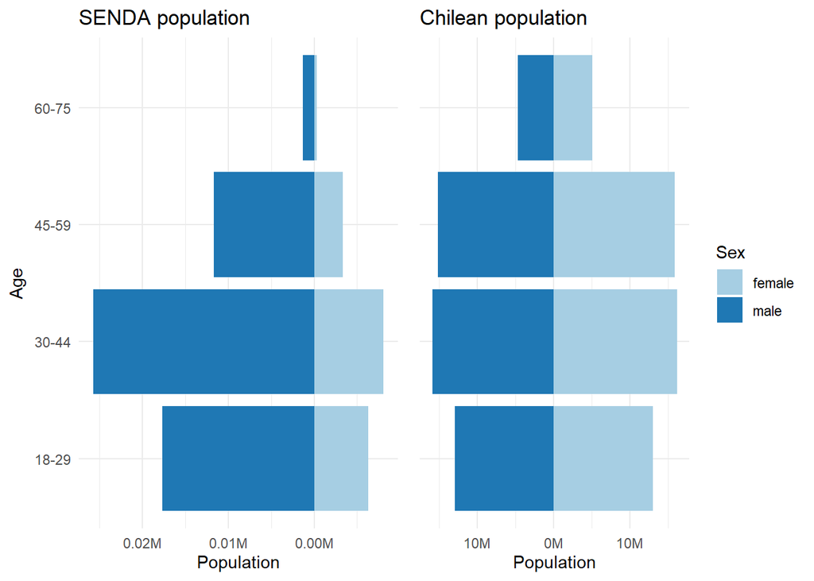

```r
ggsave(paste0(getwd(),"/_figs/pyramid.png"), dpi = 600, width = 9)
```

Saving 9 x 5 in image